# Automation of statistic summary and analysis using R Shiny

Lihai Song, Zi Wang, Jing Huang

8/26/2022

# Background

- Basic statistical analyses, e.g. summary statistics, regression analysis and testing of association, are used in almost all the medical research.
- Researchers with less/no experience of R statistical programming are struggling to make effective statistical analysis.
- Repeated work can be tedious and inconsistent.
- Reproducibility require tremendous effort of logging and documenting.

# Hurdles

Often time, researchers are facing hurdles like:

- Find the right packages for certain tasks can be challenging.
- Syntax across packages vary dramatically.
- Typo and variable name cases can cause confusions.
- Not all output has the right file formats.

[figure not shown]

# Solutions

To overcome these, a solution should address those concerns:

- Incorporate many common used packages into one.
- Keep syntax consistent across analysis.
- Remove the need to type data entries.
- One place for redo analysis without concerning of version issues.
- Provide output in various file formats.

# R shiny app

We developed a R shiny app that automates basic statistical analysis, produces publishable tables and figures.  
It takes advantage of intuitive and interactive features of shiny apps UI to address those concerns.

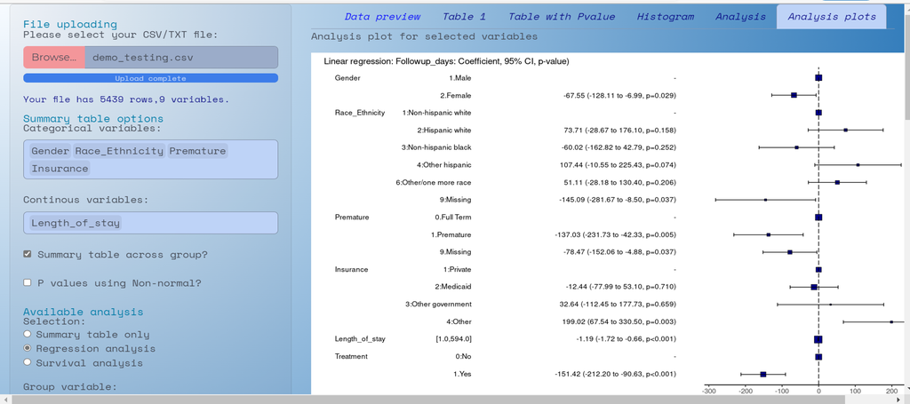

# Features

- A click and choose UI, no typing is needed.
- Supports commonly used R packages for generating tables and figures.
- Provide download buttons for commonly used file formats(Excel, PDF etc).
- Interactive explanatory analysis within the app.
- Consistency of analysis make reproducible possible.

# Demo

We would like to use a hypothetical data set to demonstrate this app.

[App demo](https://chopdsbu.shinyapps.io/Stats/)

# Thank you!

This work won’t be possible without:

- R packages developers for statistical analysis.
- Rstudio for the amazing R shiny.
- Start up fund from the Children’s Hospital of Philadelphia and University of Pennsylvania .
- National Institute of Health (NIH R01HD099348).

We appreciate your comments and feedback!

[figure not shown]